# Assignment-4-FML

```r
# Based on the plot, we can choose the number of clusters, e.g., 5
# Perform k-means clustering with the chosen number of clusters
k <- 5
set.seed(123)
kmeans_result <- kmeans(df_scale, centers = k)

k5<- kmeans(df, centers = 5, nstart=25 )
k5$centers  #centroids
```

```
##   Market_Cap      Beta PE_Ratio   ROE       ROA Asset_Turnover Leverage
## 1 127.335000 0.4050000 18.45000 51.75 17.650000      1.0500000 0.310000
## 2 186.700000 0.5550000 26.00000 37.10 17.750000      0.8500000 0.130000
## 3  60.917500 0.3962500 20.21250 29.60 12.650000      0.7000000 0.380000
## 4   4.492857 0.7342857 20.72857 14.40  5.371429      0.5428571 1.061429
## 5  31.910000 0.4050000 69.50000 13.20  5.600000      0.7500000 0.475000
##   Rev_Growth Net_Profit_Margin
## 1   19.61000          17.60000
## 2   17.45500          21.55000
## 3    8.06125          19.56250
## 4   16.85857          11.71429
## 5   12.08000           6.40000
```

```r
# size of cluster
k5$size
```

```
## [1] 2 2 8 7 2
```

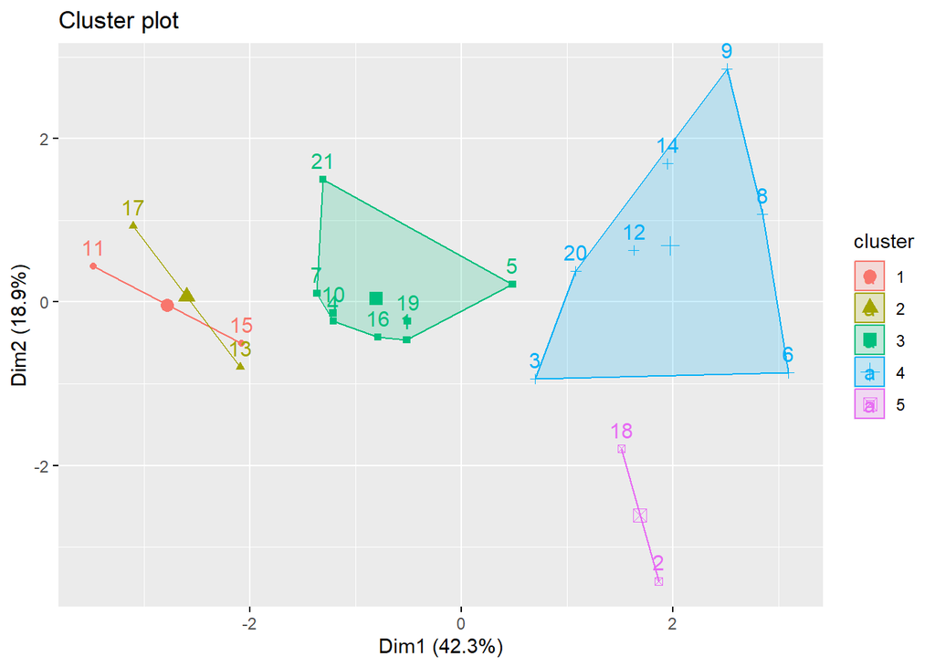

```r
fviz_cluster(k5,data=df)
```

#Analysis of each cluster’s characteristics will provide insights into the structure of the pharmaceutical industry based on market capitalization, beta, P/E ratio, ROI, ROA, asset turnover, leverage, and revenue growth.

```r
# Cluster mean values of numerical variables for each cluster
cluster_means <- aggregate(. ~ cluster, data = cbind(pharma_data[, 3:11], cluster = kmeans_result$cluster), FUN = mean)
print(cluster_means)
```

```
##   cluster Market_Cap      Beta PE_Ratio    ROE       ROA Asset_Turnover
## 1       1  157.01750 0.4800000 22.22500 44.425 17.700000      0.9500000
## 2       2   45.56000 0.4620000 19.94000 25.220 12.680000      0.8400000
## 3       3    9.23500 0.6483333 19.43333 17.300  5.983333      0.4833333
## 4       4   26.90667 0.6400000 55.63333 10.100  4.200000      0.7000000
## 5       5   72.89333 0.3333333 20.86667 34.600 12.700000      0.5666667
##    Leverage Rev_Growth Net_Profit_Margin
## 1 0.2200000  18.532500         19.575000
## 2 0.2520000   8.170000         16.700000
## 3 1.2500000  23.490000         13.516667
## 4 0.3166667   6.996667          5.133333
## 5 0.5700000   1.293333         23.766667
```

```r
# Interpret the clusters based on the average values of numerical variables
for (i in 1:nrow(cluster_means)) {
  cat("Cluster", i, ":\n")
  cat("Average Market Capitalization:", cluster_means[i, "Market_Cap"], "\n")
  cat("Average Beta:", cluster_means[i, "Beta"], "\n")
  cat("Average PE Ratio:", cluster_means[i, "PE_Ratio"], "\n")
  cat("Average ROE:", cluster_means[i, "ROE"], "\n")
  cat("Average ROA:", cluster_means[i, "ROA"], "\n")
  cat("Average Asset Turnover:", cluster_means[i, "Asset_Turnover"], "\n")
  cat("Average Leverage:", cluster_means[i, "Leverage"], "\n")
  cat("Average Estimated Revenue Growth:", cluster_means[i, "Rev_Growth"], "\n")
  cat("Average Net Profit Margin:", cluster_means[i, "Net_Profit_Margin"], "\n\n")
}
```

```
## Cluster 1 :
## Average Market Capitalization: 157.0175
## Average Beta: 0.48
## Average PE Ratio: 22.225
## Average ROE: 44.425
## Average ROA: 17.7
## Average Asset Turnover: 0.95
## Average Leverage: 0.22
## Average Estimated Revenue Growth: 18.5325
## Average Net Profit Margin: 19.575
##
## Cluster 2 :
## Average Market Capitalization: 45.56
## Average Beta: 0.462
## Average PE Ratio: 19.94
## Average ROE: 25.22
## Average ROA: 12.68
## Average Asset Turnover: 0.84
## Average Leverage: 0.252
## Average Estimated Revenue Growth: 8.17
## Average Net Profit Margin: 16.7
##
## Cluster 3 :
## Average Market Capitalization: 9.235
## Average Beta: 0.6483333
## Average PE Ratio: 19.43333
## Average ROE: 17.3
## Average ROA: 5.983333
## Average Asset Turnover: 0.4833333
## Average Leverage: 1.25
## Average Estimated Revenue Growth: 23.49
## Average Net Profit Margin: 13.51667
##
## Cluster 4 :
## Average Market Capitalization: 26.90667
## Average Beta: 0.64
## Average PE Ratio: 55.63333
## Average ROE: 10.1
## Average ROA: 4.2
## Average Asset Turnover: 0.7
## Average Leverage: 0.3166667
## Average Estimated Revenue Growth: 6.996667
## Average Net Profit Margin: 5.133333
##
## Cluster 5 :
## Average Market Capitalization: 72.89333
## Average Beta: 0.3333333
## Average PE Ratio: 20.86667
## Average ROE: 34.6
## Average ROA: 12.7
## Average Asset Turnover: 0.5666667
## Average Leverage: 0.57
## Average Estimated Revenue Growth: 1.293333
## Average Net Profit Margin: 23.76667
```

#Non-numerical variables (10 to 12) will be analyzed across clusters to identify any patterns or trends.The median recommendation, location of the firm’s headquarters, and stock exchange listing might reveal geographical or market-specific trends among clusters.

[figure not shown]

```r
# Creating a function to plot bar plots for non-numerical variables by cluster
plot_non_numerical <- function(variable) {
  ggplot(pharma_data, aes(x = k5$cluster, fill = variable)) +
    geom_bar(position = "stack") +
    labs(x = "cluster", y = "frequency", fill = variable, title = paste("Bar plot of", variable, "by Cluster")) +
    theme_minimal()
}

# Plotting bar plots for non-numerical variables (10 to 12)
plot_non_numerical("Median_Recommendation")
```

[figure not shown]

```r
plot_non_numerical("Location")
```

[figure not shown]

```r
plot_non_numerical("Exchange")
```

#Each cluster can be appropriately named based on the dominant financial and non-financial characteristics observed.Cluster names reflect key features such as market capitalization, leverage, profitability, efficiency, etc.

```r
# Create a function to generate cluster names based on cluster characteristics
generate_cluster_names <- function(cluster_means) {
  cluster_names <- character(nrow(cluster_means))
  for (i in 1:nrow(cluster_means)) {
    # Extract relevant variables for cluster naming
    market_cap <- cluster_means[i, "Market_Cap"]
    leverage <- cluster_means[i, "Leverage"]
    roe <- cluster_means[i, "ROE"]
    rev_growth <- cluster_means[i, "Rev_Growth"]

    # Derive the cluster names based on characteristics
    if (market_cap > 100 && leverage < 0.5) {
      cluster_names[i] <- "High Market Cap, Low Leverage"
    } else if (market_cap < 10 && leverage > 1) {
      cluster_names[i] <- "Low Market Cap, High Leverage"
    } else if (roe > 30 && rev_growth > 15) {
      cluster_names[i] <- "HighROE_HighGrowth"
    } else {
      cluster_names[i] <- "General"
    }
  }
  return(cluster_names)
}

cluster_names <- generate_cluster_names(cluster_means)

# Add cluster names to the cluster_means dataframe
cluster_means$cluster_name <- cluster_names
print(cluster_means[, c("cluster", "cluster_name")])
```

```
##   cluster                  cluster_name
## 1       1 High Market Cap, Low Leverage
## 2       2                       General
## 3       3 Low Market Cap, High Leverage
## 4       4                       General
## 5       5                       General
```

```r
#Hierarchy clustering is a class of clustering algorithms that organize data points into a hierarchical structure or tree-like hierarchy based on their similarity
hierarchycluster_result <- hclust(dist(df_scale), method = "ward.D2")
# Cut the dendrogram to create a specified number of clusters.
cluster <- cutree(hierarchycluster_result, k = 5)
cluster
```

```
##  [1] 1 2 3 1 3 2 1 4 3 1 5 3 5 3 5 1 5 2 1 3 1
```

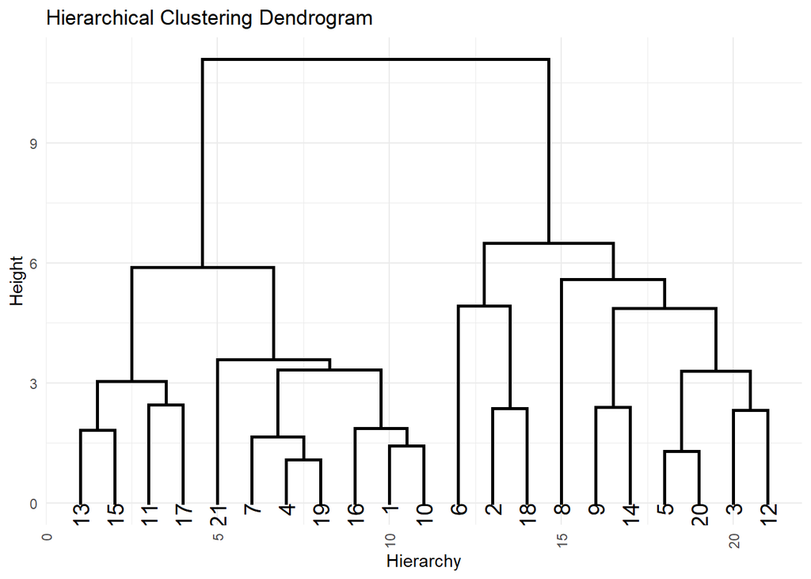

```r
dendrogram <- as.dendrogram(hierarchycluster_result)
ggplotdend <- as.ggdend(dendrogram)
ggplot(ggplotdend, theme = theme_minimal()) +
  labs(title = "Hierarchical Clustering Dendrogram", x = "Hierarchy", y = "Height") +
  theme(axis.text.x = element_text(angle = 90, hjust = 1, vjust = 0.5))
```